# Introduction

## Business Case: Finding meaninful drivers of the Human Pulse rate

[output not shown]

# Data Description

```r
    survey <- read.csv("survey.csv")
    str(survey)
```

```
## 'data.frame':    237 obs. of  13 variables:
##  $ X     : int  1 2 3 4 5 6 7 8 9 10 ...
##  $ Sex   : Factor w/ 2 levels "Female","Male": 1 2 2 2 2 1 2 1 2 2 ...
##  $ Wr.Hnd: num  18.5 19.5 18 18.8 20 18 17.7 17 20 18.5 ...
##  $ NW.Hnd: num  18 20.5 13.3 18.9 20 17.7 17.7 17.3 19.5 18.5 ...
##  $ W.Hnd : Factor w/ 2 levels "Left","Right": 2 1 2 2 2 2 2 2 2 2 ...
##  $ Fold  : Factor w/ 3 levels "L on R","Neither",..: 3 3 1 3 2 1 1 3 3 3 ...
##  $ Pulse : int  92 104 87 NA 35 64 83 74 72 90 ...
##  $ Clap  : Factor w/ 3 levels "Left","Neither",..: 1 1 2 2 3 3 3 3 3 3 ...
##  $ Exer  : Factor w/ 3 levels "Freq","None",..: 3 2 2 2 3 3 1 1 3 3 ...
##  $ Smoke : Factor w/ 4 levels "Heavy","Never",..: 2 4 3 2 2 2 2 2 2 2 ...
##  $ Height: num  173 178 NA 160 165 ...
##  $ M.I   : Factor w/ 2 levels "Imperial","Metric": 2 1 NA 2 2 1 1 2 2 2 ...
##  $ Age   : num  18.2 17.6 16.9 20.3 23.7 ...
```

Above is the description of the data that I will be examining to get the point of Pulses across.

//Data Specifics

Observations - 237

Variables - 13

Dependent Variable = Pulse Independent Variables = [ Age, Sex, Exer, Smoke, Writing Hand, Writing Hand Length, Non Writing Hand Length, Fold, Clap, Height ]

//Equation Pulse = b0, b1 * Age, B2 * Writing Hand, B3 * Sex, B4 * Height, B5 * Height

# Analysis, Results and Discussion

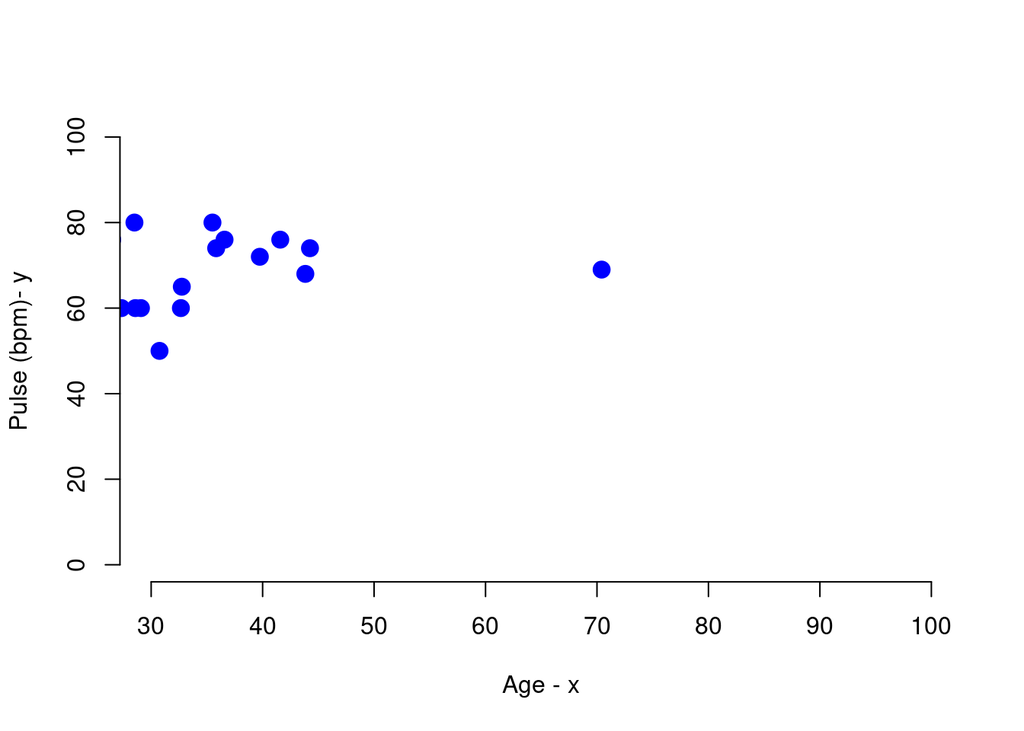

```r
plot(survey$Pulse ~ survey$Age, pch=19, col="blue", cex=1.5, xlim=c(30,100), ylim=c(0,100), xlab="Age - x", ylab="Pulse (bpm)- y", frame.plot = FALSE)
```

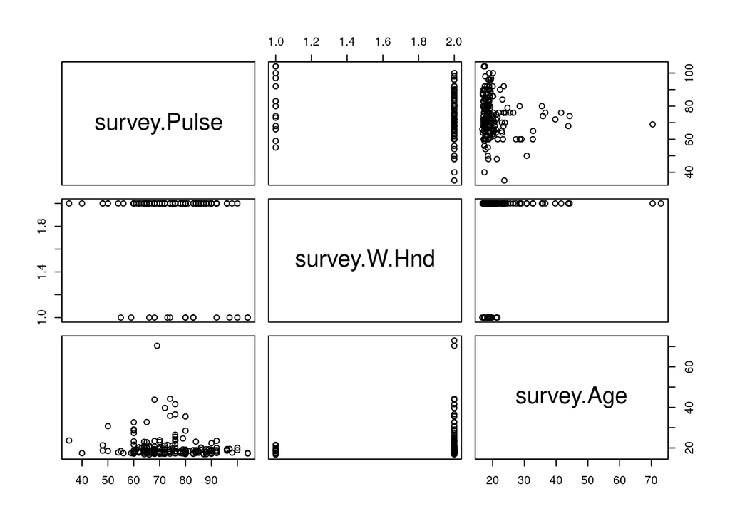

```r
    pulp <- data.frame(survey$Pulse, survey$W.Hnd, survey$Age)
    pairs(pulp)
```

The data does not seem to have a positive or negative linear trend for any of the variables that are listed above. This is more corroboration that Pulse is based on something other than information supplied in the given dataset.

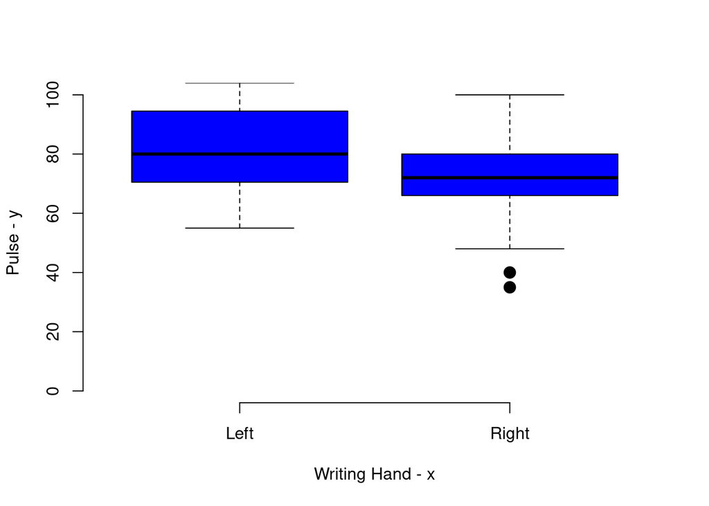

```r
    plot(survey$Pulse ~ survey$W.Hnd, pch=19, col="blue", cex=1.5, ylim=c(0,100), xlab="Writing Hand - x", ylab="Pulse - y", frame.plot = FALSE)
```

Looking at the plot above, we may be on to something based on an unorthodox variable. The and that one write’s with seems to be telling us something that we need to give more attention.

```r
    impulse<- lm(survey$Pulse ~ survey$Sex+survey$Wr.Hnd+survey$NW.Hnd+survey$W.Hnd+survey$Fold+survey$Clap+survey$Exer+survey$Smoke+survey$Height+survey$M.I+survey$Age)
    summary(impulse)
```

```
##
## Call:
## lm(formula = survey$Pulse ~ survey$Sex + survey$Wr.Hnd + survey$NW.Hnd +
##     survey$W.Hnd + survey$Fold + survey$Clap + survey$Exer +
##     survey$Smoke + survey$Height + survey$M.I + survey$Age)
##
## Residuals:
##     Min      1Q  Median      3Q     Max
## -36.072  -6.826  -0.019   7.574  24.152
##
## Coefficients:
##                      Estimate Std. Error t value Pr(>|t|)
## (Intercept)        106.606329  24.068638   4.429 1.81e-05 ***
## survey$SexMale      -0.007963   2.730281  -0.003   0.9977
## survey$Wr.Hnd        0.029189   1.846635   0.016   0.9874
## survey$NW.Hnd        0.105542   1.775373   0.059   0.9527
## survey$W.HndRight   -8.731426   3.600786  -2.425   0.0165 *
## survey$FoldNeither  -5.060406   4.402644  -1.149   0.2522
## survey$FoldR on L    0.242295   1.837766   0.132   0.8953
## survey$ClapNeither  -1.596625   2.979332  -0.536   0.5928
## survey$ClapRight     0.744662   2.555156   0.291   0.7711
## survey$ExerNone      3.535592   3.402252   1.039   0.3004
## survey$ExerSome      4.042228   1.966355   2.056   0.0415 *
## survey$SmokeNever   -5.114316   4.552583  -1.123   0.2631
## survey$SmokeOccas   -6.921764   5.499751  -1.259   0.2101
## survey$SmokeRegul   -0.876687   5.377681  -0.163   0.8707
## survey$Height       -0.115837   0.142851  -0.811   0.4187
## survey$M.IMetric     0.116223   1.887341   0.062   0.9510
## survey$Age          -0.215677   0.150902  -1.429   0.1550
## ---
## Signif. codes:  0 '***' 0.001 '**' 0.01 '*' 0.05 '.' 0.1 ' ' 1
##
## Residual standard error: 11.31 on 151 degrees of freedom
##   (69 observations deleted due to missingness)
## Multiple R-squared:  0.1313, Adjusted R-squared:  0.0392
## F-statistic: 1.426 on 16 and 151 DF,  p-value: 0.1365
```